# MA615 Final Assignment - STRAWBERRY Project

Fan Feng

2020/10/19

# MA615 Unit 1 Final Assignment – Strawberry Project

## ABSTRACT

This the Final Assignment of MA615 2020. this assignment combines data cleaning, data organization, and EDA – which is how it generally happens. You may use either of the red berries for the assignment. Finish cleaning and organizing the data. Visualize and explore the data. Prepare a report, a presentation, and a shiny application describing what you did and what you learned. Using markdown (perhaps with some additional LaTeX and HTML), format the document with headings, tables, lists, and so on. Be prepared to use your presentation slides in class. Publish your shiny app on shinyapps.io. To provide a focus for the deliverables, imagine that you are cleaning, organizing, and exploring the dataset before releasing it to an agricultural research team for analysis and modeling.

## Part 1: Data Cleaning & Organization

### 1.1 Acquire and process the raw data

These data were collected from the USDA database selector: https://quickstats.nass.usda.gov

First, we load the raw dataset into ‘berry_data’. However, data selected from the NASS database often has columns without any data or with a single repeated Values. Therefore, we check the unique values in each column to remove the useless columns having only one unique value. Also, there are some columns containing the redundant information, such as ‘State’ column and ‘State ANSI’ column. So we only keep the ‘State’ column which shows the state name.

```r
## read the raw data
berry_data <- read_csv("berries.csv", col_names = TRUE)
## look at number of unique values in each column
col_unique <- berry_data %>% summarize_all(n_distinct)
## make a list of the columns with only one unique value
no_use <- which(col_unique[1,]==1)
## list the 1-unique valu column names
cn <- colnames(berry_data)[no_use]
## remove the 1-unique columns from the dataset
berry_data %<>% select(-all_of(no_use))
col_unique %<>% select(-all_of(no_use))
## State name and the State ANSI code are (sort of) redundant
berry_data %<>% select(-`State ANSI`)
col_unique %<>% select(-`State ANSI`)
```

According to our analysis, the berries data had only 8 out of 21 columns containing meaningful data. Based on the preliminary analysis, most of the contents of the data set are useful.

```r
head(berry_data)
```

| Year | Period | State | Commodity | Data Item | Domain | Domain Category | Value |
| --- | --- | --- | --- | --- | --- | --- | --- |
| 2019 | MARKETING YEAR | CALIFORNIA | BLUEBERRIES | BLUEBERRIES, TAME - PRICE RECEIVED, MEASURED IN $ / LB | TOTAL | NOT SPECIFIED | 2.85 |
| 2019 | MARKETING YEAR | CALIFORNIA | BLUEBERRIES | BLUEBERRIES, TAME, FRESH MARKET - PRICE RECEIVED, MEASURED IN $ / LB | TOTAL | NOT SPECIFIED | 3.56 |
| 2019 | MARKETING YEAR | CALIFORNIA | BLUEBERRIES | BLUEBERRIES, TAME, PROCESSING - PRICE RECEIVED, MEASURED IN $ / LB | TOTAL | NOT SPECIFIED | 0.29 |
| 2019 | MARKETING YEAR | CALIFORNIA | RASPBERRIES | RASPBERRIES - PRICE RECEIVED, MEASURED IN $ / LB | TOTAL | NOT SPECIFIED | 2.69 |
| 2019 | MARKETING YEAR | CALIFORNIA | RASPBERRIES | RASPBERRIES, FRESH MARKET - PRICE RECEIVED, MEASURED IN $ / LB | TOTAL | NOT SPECIFIED | (D) |
| 2019 | MARKETING YEAR | CALIFORNIA | RASPBERRIES | RASPBERRIES, PROCESSING - PRICE RECEIVED, MEASURED IN $ / LB | TOTAL | NOT SPECIFIED | (D) |

### 1.2 Focus on Strawberry data and cleaning in depth

This table contains informaton about three different berries: blueberries, raspberries, and strawberries. Since the raw data have been cleaned and organized, the three kinds of berries will be separted into tables with the same stucture so that they can be compared. In this project, we will only work with strawberry data and Only the “YEAR” time periond will be considered.

```r
berry_type<- unique(berry_data$Commodity)
nberry <- length(berry_type)

strawberry <- berry_data %>%
  filter((Commodity=="STRAWBERRIES") & (Period=="YEAR")) %<>%
  select(-c(Period, Commodity))
```

#### Cleaning the ‘Data Item’ column

Looking at the data brifely, we can notice that the column ‘Data Item’ contains composite information. Thus, we try to seperate the content of each entry by comma. In the end, the ‘Data Item’ will be turned into several columns such as ‘type’, ‘meas’, ‘what’.

```r
#### Does every Data Item begin with "STRAWBERRIES"
sum(str_detect(strawberry$`Data Item`, "^STRAWBERRIES")) ==
  length(strawberry$`Data Item`)
```

```
## [1] TRUE
```

```r
strawberry %<>%
  separate(`Data Item`,c("Berry","item"), sep = 14) %<>%
  select(-Berry)
#nchar("STRAWBERRIES") = 12

strawberry %<>% separate(item, c("what","meas","how"), sep = ',')
```

```r
#strawberry %>%filter(what == "PROCESSING")
strawberry %<>% mutate(meas = ifelse(what =="PROCESSING",how,meas))
strawberry %<>% mutate(how = ifelse(what == "PROCESSING","",how))
```

Repeat the process for ‘what’ == ‘FRESH MARKET’

```r
strawberry %<>%
  mutate(what = ifelse(what == "FRESH MARKET", "FRESH MARKET - UTILIZED - PRODUCTION", what)) %<>%
  mutate(meas = ifelse(what == "FRESH MARKET - UTILIZED - PRODUCTION", how, meas)) %<>%
  mutate(how = ifelse(what == "FRESH MARKET - UTILIZED - PRODUCTION", "", how))
```

Now Lets check whether we have finished the cleaing of the “Data Item” Part.

```r
strawberry %>% summarize_all(n_distinct)
```

| Year | State | what | meas | how | Domain | Domain Category | Value |
| --- | --- | --- | --- | --- | --- | --- | --- |
| 5 | 11 | 12 | 10 | 3 | 6 | 162 | 763 |

```r
#strawberry$how %>% unique()
#strawberry$what %>% unique()
#strawberry$meas %>% unique()
```

#### Cleaning the ‘Domain’ & ‘Domain Category’ columns

```r
#Separate by ","
strawberry %<>% separate(Domain, c("Category", "chemi_type"), sep = ", ")
strawberry %<>% separate(`Domain Category`, c("DC_left", "DC_right"), sep = ", ")
strawberry[is.na(strawberry)] <- ""

## work on DC_left first
strawberry %<>% separate(DC_left, c("DC_left_l", "ferti_info"), sep = ": ")
strawberry %<>% separate(DC_right, c("DC_right_l", "chemi_info"), sep = ": ")
strawberry[is.na(strawberry)] <- ""
```

OK now we need to eliminate the redundancy and rename a column to make it more clear and comprehensible.

```r
## remove column strawberry$DC_left_l
strawberry %<>%  select(-DC_left_l, -DC_right_l)
## turn the 'meas' column into the 'unit' column
strawberry %<>%
  separate(meas, c("meas", "unit"), sep = 13) %<>%
  select(-meas)
```

Last but not least, we notice that the ‘Value’ column contains the important information and we need transform it into numeric and replace the NAs.

```r
# Set Value to be numeric
strawberry$Value <-as.numeric(gsub(pattern = ",", replacement = "",strawberry$Value))
strawberry[is.na(strawberry)] <- 0
```

Finally, let’s save the file:

```r
write.csv(strawberry, "cleaned_strawberry.csv")
```

## Part 2: Exploratory Data Analysis

Based on the cleaned dataset above, we find that, in the ‘what’ column, the data we have shows different indexes of the agriculture, including ACRES HARVESTED, ACRES PLANTED, PRODUCTION, YIELD and so on. What is more, some indexes are measured by different units. For example, the ‘PRODUCTION’ is measured by both $ and CWT.

Therefore, we decide to divide the cleaned dataset into several parts and perform the exploratory data analysis on them respectively.

### Divide the dataset from different levels

```r
# Divide by the what column
AH <- strawberry %>% filter(what == ' ACRES HARVESTED')
AP <- strawberry %>% filter(what == ' ACRES PLANTED')
prod <- strawberry %>% filter(what == ' PRODUCTION')
yield <- strawberry %>% filter(what == ' YIELD')

# Divide by the Category column
total <- subset(strawberry, Category == "TOTAL")
chemi <- subset(strawberry, Category == 'CHEMICAL')
ferti <- subset(strawberry, Category == 'FERTILIZER')
```

### Production data for each state across the years

```r
# PRODUCTION divide by different units
prod_dollar <- subset(prod, unit == "$")
prod_cwt <- subset(prod, unit == "CWT")
```

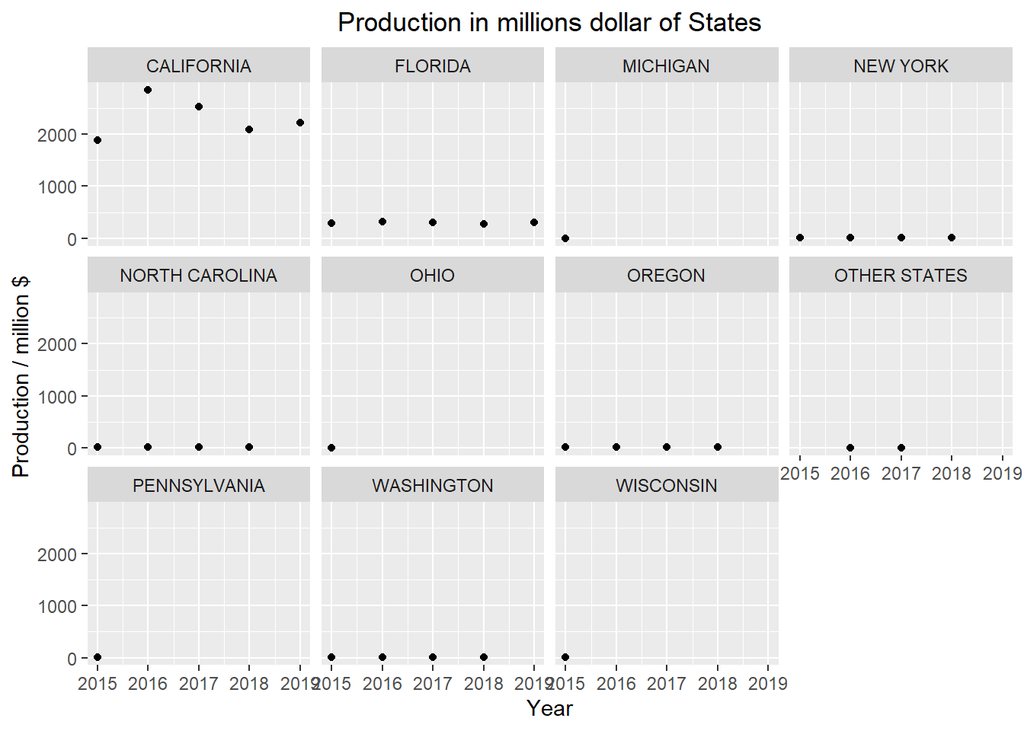

```r
# Plot production in $ by each state
ggplot(prod_dollar, aes(prod_dollar$Year,prod_dollar$Value/1000000)) +
  geom_point() +
  facet_wrap(~State) +
  ggtitle("Production in millions dollar of States") +
  labs(y="Production / million $ ", x = "Year") +
  theme(plot.title = element_text(hjust = 0.5))
```

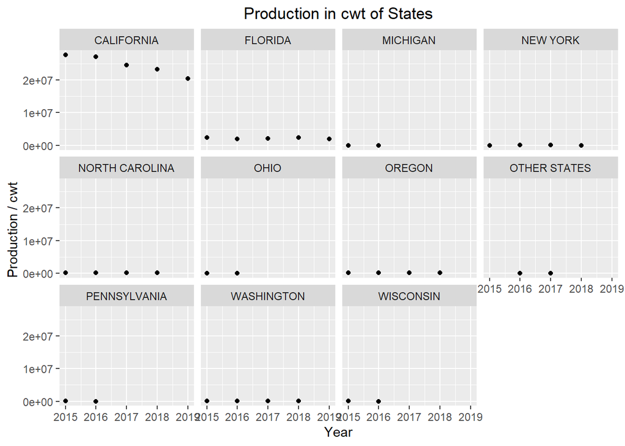

```r
## Plot production in cwt by each state
ggplot(prod_cwt, aes(prod_cwt$Year,prod_cwt$Value)) +
  geom_point() +
  facet_wrap(~State) +
  ggtitle("Production in cwt of States") +
  labs(y="Production / cwt ", x = "Year") +
  theme(plot.title = element_text(hjust = 0.5))
```

The above graphs show that California has the highest value of strawberry productions over the years 2015 to 2019, Florida has the second highest production value.

### Acres Harvested data for each state across the years

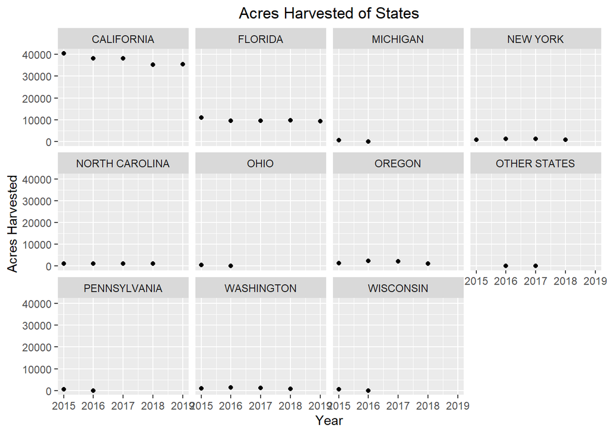

```r
ggplot(AH, aes(AH$Year,AH$Value)) +
  geom_point() +
  facet_wrap(~State) +
  ggtitle("Acres Harvested of States") +
  labs(y="Acres Harvested ", x = "Year") +
  theme(plot.title = element_text(hjust = 0.5))
```

### Arces planted data for each state across the years

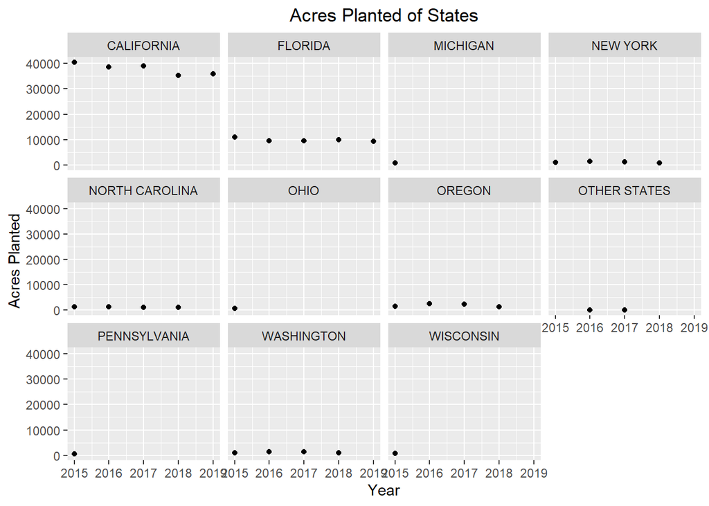

```r
ggplot(AP, aes(AP$Year, AP$Value)) +
  geom_point() +
  facet_wrap(~State) +
  ggtitle("Acres Planted of States") +
  labs(y="Acres Planted ", x = "Year") +
  theme(plot.title = element_text(hjust = 0.5))
```

### Yield data for each state across the years

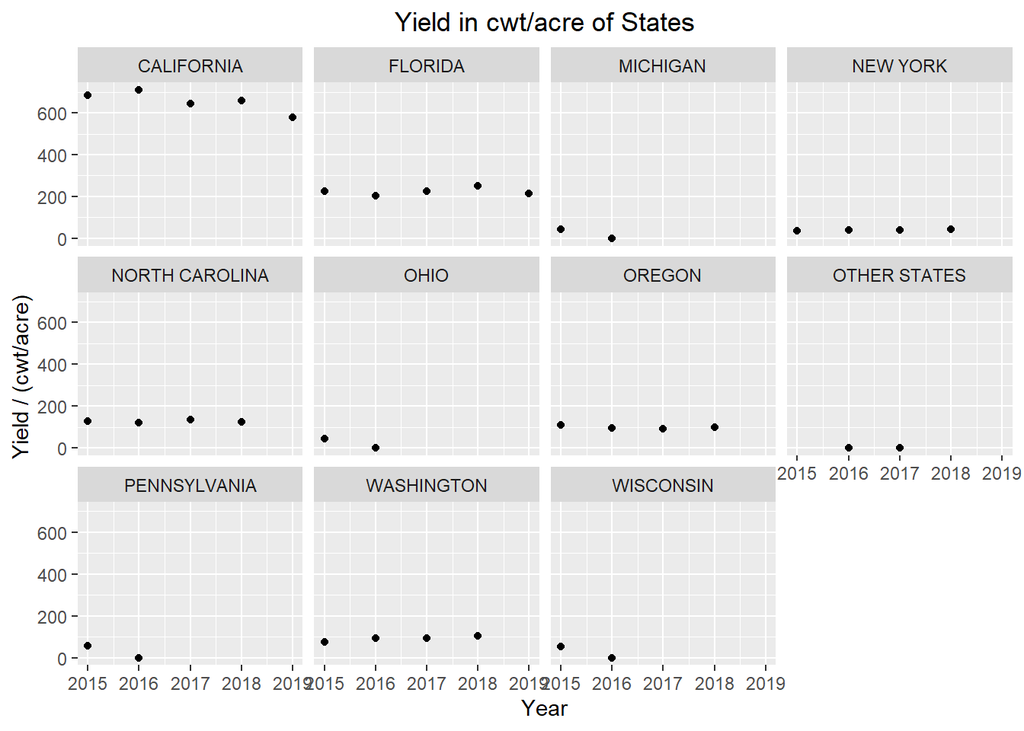

```r
ggplot(yield, aes(yield$Year, yield$Value)) +
  geom_point() +
  facet_wrap(~State) +
  ggtitle("Yield in cwt/acre of States") +
  labs(y="Yield / (cwt/acre) ", x = "Year") +
  theme(plot.title = element_text(hjust = 0.5))
```

### Measurement Analysis

Firstly, let’s count how many different types of unit are used in measurement.

```r
meas_unit <- strawberry %>%
  group_by(unit) %>%
  summarize(count = n(),
            Mean.Value = round(mean(Value),2))
length(meas_unit$unit) - 1
```

```
## [1] 9
```

So, there are 9 types of unit used in measurement in the strawberry data set. Next, Lets make a bar plot to see the frequency of the units used.

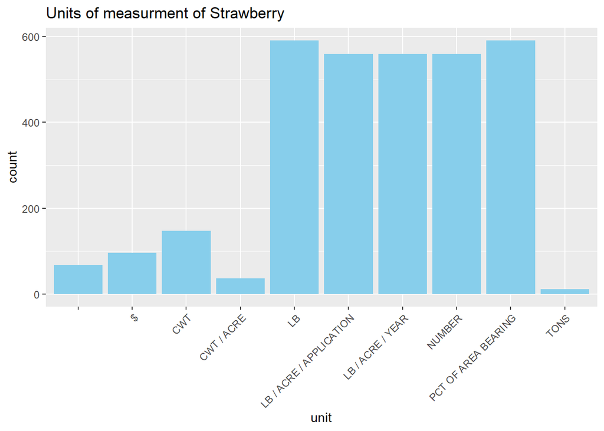

```r
# frequency of unit used
ggplot(strawberry,aes(unit))+
  geom_bar(fill = "sky blue") +
  ggtitle("Units of measurment of Strawberry") +
  theme(axis.text.x = element_text(angle = 45,hjust = 1))
```

Based on the plot above, the ‘PCT OF AREA BEARING’ is used most frequently and ‘TONS’ is used for the least times. And we can notice that, there are also many indexes do not have units.

## Part 3: Reference

This project references to Haviland’s codes of data acquiring and reading, and receives help from Zhiwei Liang and Chenxun Li about how to transform characters to numeric forms, and what type of visualizations to implement.

This berries project uses packages tidyverse(Wickham et al., 2019), ggplot2(H. Wickham, 2016), kableExtra(Hao Zhu, 2020), and magrittr(S. M. Bache and H. Wickham, 2014) for data cleaning. The final report is complied by knitr(Yihui Xie, 2020), app is built using package shiny(Winston Chang, Joe Cheng, JJ Allaire, Yihui Xie and Jonathan McPherson, 2020)